# Reproducible Research: Peer Assessment 1

Francisco Javier Carela Ferrer

October, 2020

```r
library(dplyr)
```

```r
library(ggplot2)
library(ggthemes)
```

## 0.1 Loading and preprocessing the data

First, you have to choose your working directory, and next, using read.csv() function to introduce the dataset in the environment

```r
#setwd("~/projects/GitHubs/RepData_PeerAssessment1")
activity <- read.csv('activity.csv')
```

After we have our dataset, we can make some transformations:

```r
activity$date<-format(as.Date(activity$date, format ="%Y-%m-%d"), format = "%d-%m-%y") #Easilly reading
mean(is.na(activity$steps))# knowledge about NA's
```

```
## [1] 0.1311475
```

```r
activity$day <- weekdays(as.Date(activity$date))
activity$DateTime<- as.POSIXct(activity$date, format="%Y-%m-%d")
```

## 0.2 What is mean total number of steps taken per day?

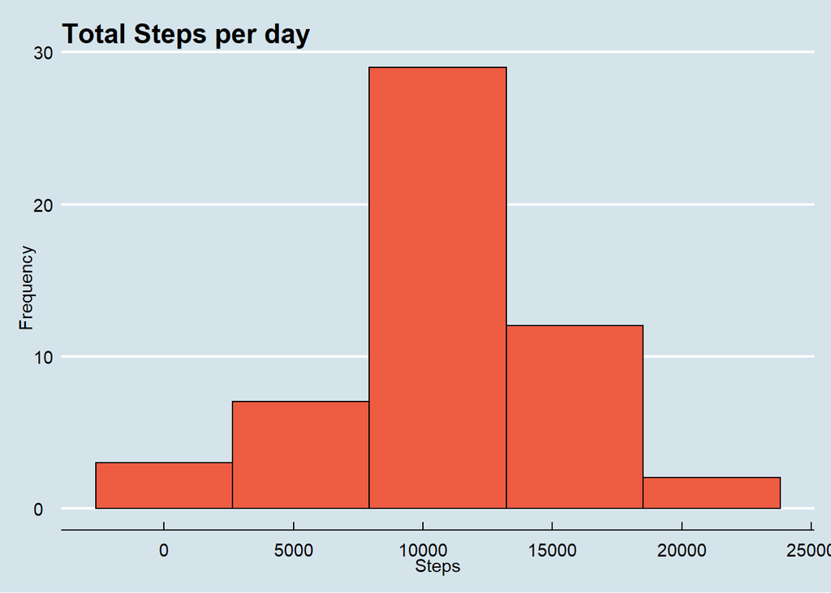

```r
sumTable <- aggregate(activity$steps ~ activity$date, FUN=sum, )
colnames(sumTable)<- c("Date", "Steps")
# We also can make an histogram with ggplot2
ggplot(sumTable, aes(x=Steps)) + geom_histogram(bins = 5,color="black", fill="tomato2") +
  theme_economist() +labs(title = "Total Steps per day") + xlab("Steps") + ylab("Frequency")
```

Now we are going to calculate the mean and median of the total number of steps taken per day

```r
round(mean(sumTable$Steps), 0)
```

```
## [1] 10766
```

```r
round(median(sumTable$Steps),0)
```

```
## [1] 10765
```

## 0.3 What is the average daily activity pattern?

First of all, we are going to delete the NA’s observations, in the *Step* variable, and next, we are goint to plotting the results:

```r
require(dplyr)
library(plyr)
```

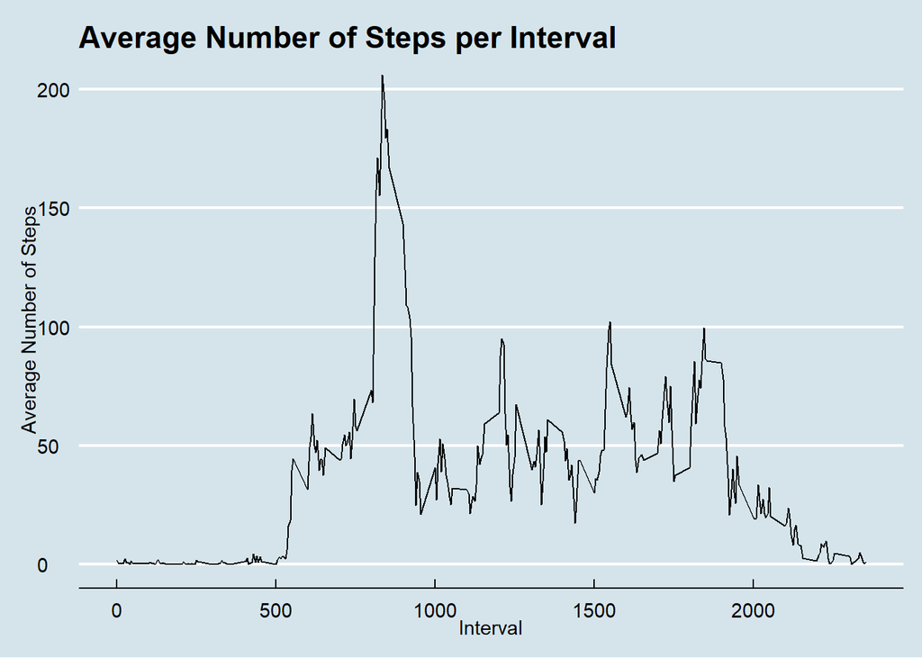

```r
clean <- activity[!is.na(activity$steps),]
intervalTable <- ddply(clean, .(interval), summarize, Avg = mean(steps))
clean <- activity[!is.na(activity$steps),]
interval_Table <- ddply(clean, .(interval), summarize, Avg = mean(steps))
ggplot(interval_Table, aes(x=interval, y=Avg), xlab = "Interval", ylab="Average Number of Steps") +
 geom_line()+xlab("Interval")+ylab("Average Number of Steps")+ggtitle("Average Number of Steps per Interval") +
  theme_economist()
```

The 5-minute interval that, on average, contains the maximum number of steps:

```r
maxSteps <- max(intervalTable$Avg)
round(maxSteps,0)
```

```
## [1] 206
```

```r
intervalTable[intervalTable$Avg==maxSteps,1]
```

```
## [1] 835
```

The maximum number of steps for a 5-minute interval is **206 steps.**

The 5-minute interval which have the maximum number of steps is the **835 interval.**

## 0.4 Imputing missing values

```r
nrow(activity[is.na(activity$steps),])
```

```
## [1] 2304
```

```r
mean(is.na(activity$steps))
```

```
## [1] 0.1311475
```

We have 2304 columns with NA’s observations (13% aprox.) The method that i’m goint to follow is to ubstitute the missing steps with the average 5-minute interval based on the day of the week.

```r
library(plyr)
library(dplyr)
clean <- activity[!is.na(activity$steps),]
intervalTable <- ddply(clean, .(interval), summarize, Avg = mean(steps))
avgTable <- ddply(clean, .(interval, day), summarize, Avg = mean(steps))
nadata<- activity[is.na(activity$steps),]
newdata<-merge(nadata, avgTable, by=c("interval", "day"))
```

Create a new dataset that is equal to the original dataset but with the missing data filled in.

```r
newdata2<- newdata[,c(6,4,1,2,5)]
colnames(newdata2)<- c("steps", "date", "interval", "day", "DateTime")
mergeData <- rbind(clean, newdata2)
```

Do these values differ from the estimates from the first part of the assignment? What is the impact of imputing missing data on the estimates of the total daily number of steps?:

```r
sumTable2 <- aggregate(mergeData$steps ~ mergeData$date, FUN=sum, )
colnames(sumTable2)<- c("Date", "Steps")
as.integer(mean(sumTable2$Steps))
```

```
## [1] 10807
```

```r
as.integer(median(sumTable2$Steps))
```

```
## [1] 11015
```

Histogram of the total number of steps taken each day after missing values are removed, using ggplot2:

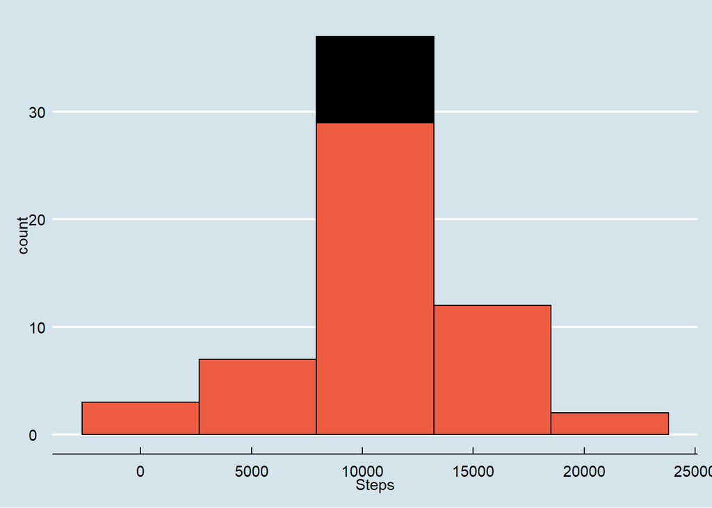

```r
ggplot() +
  geom_histogram(data = sumTable2,  aes(x = Steps), bins = 5,color="black", fill="black") +
  geom_histogram(data = sumTable,  aes(x = Steps),bins = 5,color = "black", fill = "tomato2") +
  theme_economist()
```

## 0.5 Are there differences in activity patterns between weekdays and weekends?

I’m goint to create a new factor variable in the dataset with two levels - “weekday” and “weekend” indicating whether a given date is a weekday or weekend day.

```r
library(lattice)
mergeData$DayCategory <- ifelse(mergeData$day %in% c("sabado", "domingo"), "Weekend", "Weekday")
```

It’s important to check the lenguaje of your dataset, because for example i had it in Spanish, and i have got to put “sabado” and "domingo in the *mergeData$day* colum. If you have it in English you have got to put *“Saturday”* and *“Sunday”*

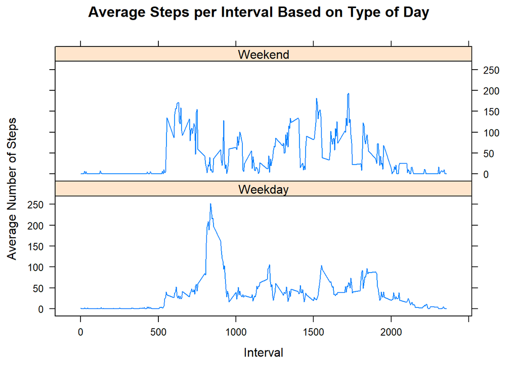

```r
intervalTable2 <- ddply(mergeData, .(interval, DayCategory), summarize, Avg = mean(steps))
xyplot(Avg~interval|DayCategory, data=intervalTable2, type="l",  layout = c(1,2),
       main="Average Steps per Interval Based on Type of Day",
       ylab="Average Number of Steps", xlab="Interval")
```

Yes, the step activity trends are different based on whether the day occurs on a weekend or not.

*Francisco Javier Carela Ferrer*